# 11 MGCFA

Rushabh Barbhaya

2021-02-06

## MGCFA Class Assignment

Using the same RS14 dataset from class, examine the multigroup analysis using `Ethnicity` as the grouping variable of interest.

## Data Libraries

Load the included dataset and libraries for this assignment.

```r
library(lavaan)
```

```r
library(rio)
library(semPlot)

data = import("assignment_mgcfa.csv")
table(data$Ethnicity)
```

```
##
##   0   1   2
##  52 106 358
```

## Data Cleanup

In this example, code 1 as Black and 2 as White. Be sure to first change the variable to a factor with labels.

```r
data$Ethnicity = factor(data$Ethnicity, levels = c(1,2), labels = c("Black", "White"))
data = subset(data, !is.na(Ethnicity))
```

## Overall CFA

In this section, build the overall one-factor CFA for the RS14. You can use the example we did in class to get started. Include the `cfa()` and `summary()` of your model here. You should call this model `overall.model`.

```r
overall.model = '
RS =~ RS1 + RS2 + RS3 + RS4 + RS5 + RS6 + RS7 + RS8 + RS9 + RS10 + RS11 + RS12 + RS13 + RS14
'
overall.fit = cfa(model = overall.model, data = data, meanstructure = T)
summary(overall.fit, standardized = T, rsquare = T, fit.measure = T)
```

```
## lavaan 0.6-7 ended normally after 26 iterations
##
##   Estimator                                         ML
##   Optimization method                           NLMINB
##   Number of free parameters                         42
##
##   Number of observations                           464
##
## Model Test User Model:
##
##   Test statistic                               339.948
##   Degrees of freedom                                77
##   P-value (Chi-square)                           0.000
##
## Model Test Baseline Model:
##
##   Test statistic                              3604.858
##   Degrees of freedom                                91
##   P-value                                        0.000
##
## User Model versus Baseline Model:
##
##   Comparative Fit Index (CFI)                    0.925
##   Tucker-Lewis Index (TLI)                       0.912
##
## Loglikelihood and Information Criteria:
##
##   Loglikelihood user model (H0)             -11904.971
##   Loglikelihood unrestricted model (H1)     -11734.997
##
##   Akaike (AIC)                               23893.942
##   Bayesian (BIC)                             24067.817
##   Sample-size adjusted Bayesian (BIC)        23934.519
##
## Root Mean Square Error of Approximation:
##
##   RMSEA                                          0.086
##   90 Percent confidence interval - lower         0.077
##   90 Percent confidence interval - upper         0.095
##   P-value RMSEA <= 0.05                          0.000
```

[output cut: 66 more lines]

```
##                    Estimate
##     RS1               0.393
##     RS2               0.453
##     RS3               0.393
##     RS4               0.440
##     RS5               0.437
##     RS6               0.528
##     RS7               0.563
##     RS8               0.495
##     RS9               0.547
##     RS10              0.488
##     RS11              0.549
##     RS12              0.459
##     RS13              0.554
##     RS14              0.661
```

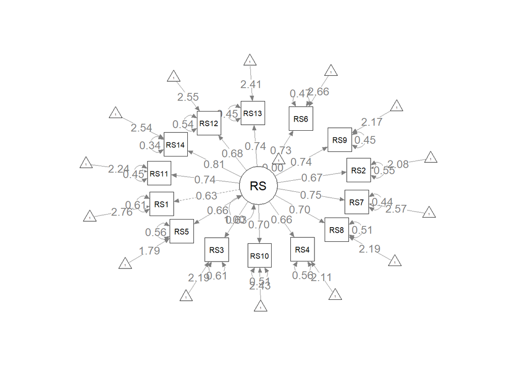

```r
semPaths(overall.fit, whatLabels = "std", layout = "spring", edge.label.cex = 1)
```

## White Overall Summary

Create a `white.fit` of the model for only White participants. Include the `summary()` of this model.

```r
white.fit = cfa(model = overall.model, data = data[data$Ethnicity == "White",], meanstructure = T)
summary(white.fit, standardized = T, rsquare = T, fit.measure = T)
```

```
## lavaan 0.6-7 ended normally after 25 iterations
##
##   Estimator                                         ML
##   Optimization method                           NLMINB
##   Number of free parameters                         42
##
##   Number of observations                           358
##
## Model Test User Model:
##
##   Test statistic                               342.834
##   Degrees of freedom                                77
##   P-value (Chi-square)                           0.000
##
## Model Test Baseline Model:
##
##   Test statistic                              2803.883
##   Degrees of freedom                                91
##   P-value                                        0.000
##
## User Model versus Baseline Model:
##
##   Comparative Fit Index (CFI)                    0.902
##   Tucker-Lewis Index (TLI)                       0.884
##
## Loglikelihood and Information Criteria:
##
##   Loglikelihood user model (H0)              -8973.138
##   Loglikelihood unrestricted model (H1)      -8801.721
##
##   Akaike (AIC)                               18030.277
##   Bayesian (BIC)                             18193.259
##   Sample-size adjusted Bayesian (BIC)        18060.015
##
## Root Mean Square Error of Approximation:
##
##   RMSEA                                          0.098
##   90 Percent confidence interval - lower         0.088
##   90 Percent confidence interval - upper         0.109
##   P-value RMSEA <= 0.05                          0.000
```

[output cut: 66 more lines]

```
##                    Estimate
##     RS1               0.410
##     RS2               0.471
##     RS3               0.428
##     RS4               0.476
##     RS5               0.445
##     RS6               0.545
##     RS7               0.563
##     RS8               0.469
##     RS9               0.515
##     RS10              0.433
##     RS11              0.541
##     RS12              0.411
##     RS13              0.544
##     RS14              0.629
```

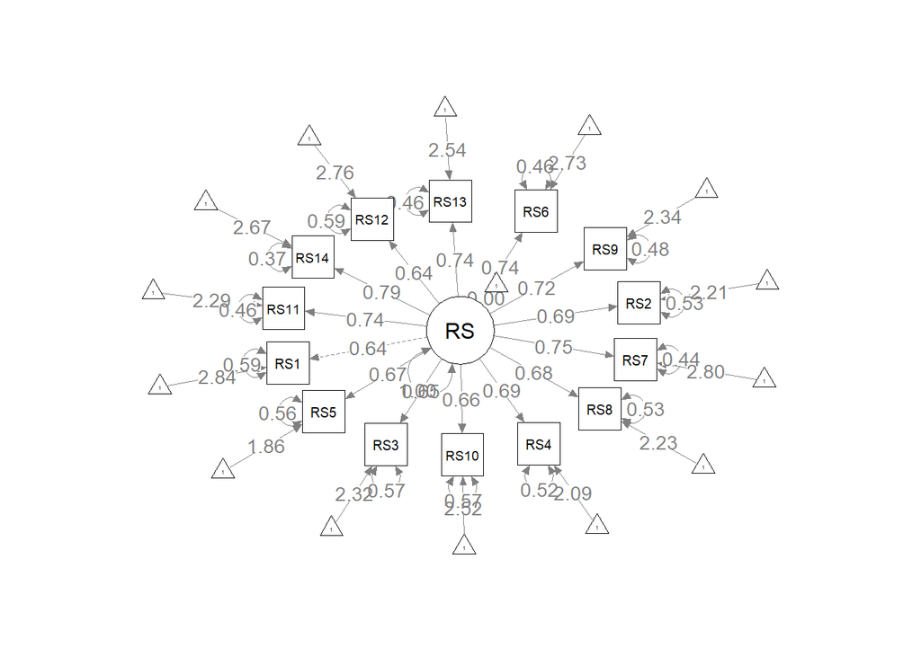

```r
semPaths(white.fit, whatLabels = "std", layout = "spring", edge.label.cex = 1)
```

## Black Overall Summary

Create a `black.fit` of the model for only Black participants. Include the `summary()` of this model.

```r
black.fit = cfa(model = overall.model, data = data[data$Ethnicity == "Black",], meanstructure = T)
summary(black.fit, standardized = T, rsquare = T, fit.measure = T)
```

```
## lavaan 0.6-7 ended normally after 28 iterations
##
##   Estimator                                         ML
##   Optimization method                           NLMINB
##   Number of free parameters                         42
##
##   Number of observations                           106
##
## Model Test User Model:
##
##   Test statistic                               125.924
##   Degrees of freedom                                77
##   P-value (Chi-square)                           0.000
##
## Model Test Baseline Model:
##
##   Test statistic                               958.962
##   Degrees of freedom                                91
##   P-value                                        0.000
##
## User Model versus Baseline Model:
##
##   Comparative Fit Index (CFI)                    0.944
##   Tucker-Lewis Index (TLI)                       0.933
##
## Loglikelihood and Information Criteria:
##
##   Loglikelihood user model (H0)              -2861.579
##   Loglikelihood unrestricted model (H1)      -2798.617
##
##   Akaike (AIC)                                5807.157
##   Bayesian (BIC)                              5919.022
##   Sample-size adjusted Bayesian (BIC)         5786.329
##
## Root Mean Square Error of Approximation:
##
##   RMSEA                                          0.077
##   90 Percent confidence interval - lower         0.052
##   90 Percent confidence interval - upper         0.101
##   P-value RMSEA <= 0.05                          0.040
```

[output cut: 66 more lines]

```
##                    Estimate
##     RS1               0.357
##     RS2               0.421
##     RS3               0.313
##     RS4               0.406
##     RS5               0.431
##     RS6               0.490
##     RS7               0.572
##     RS8               0.548
##     RS9               0.619
##     RS10              0.622
##     RS11              0.587
##     RS12              0.613
##     RS13              0.566
##     RS14              0.753
```

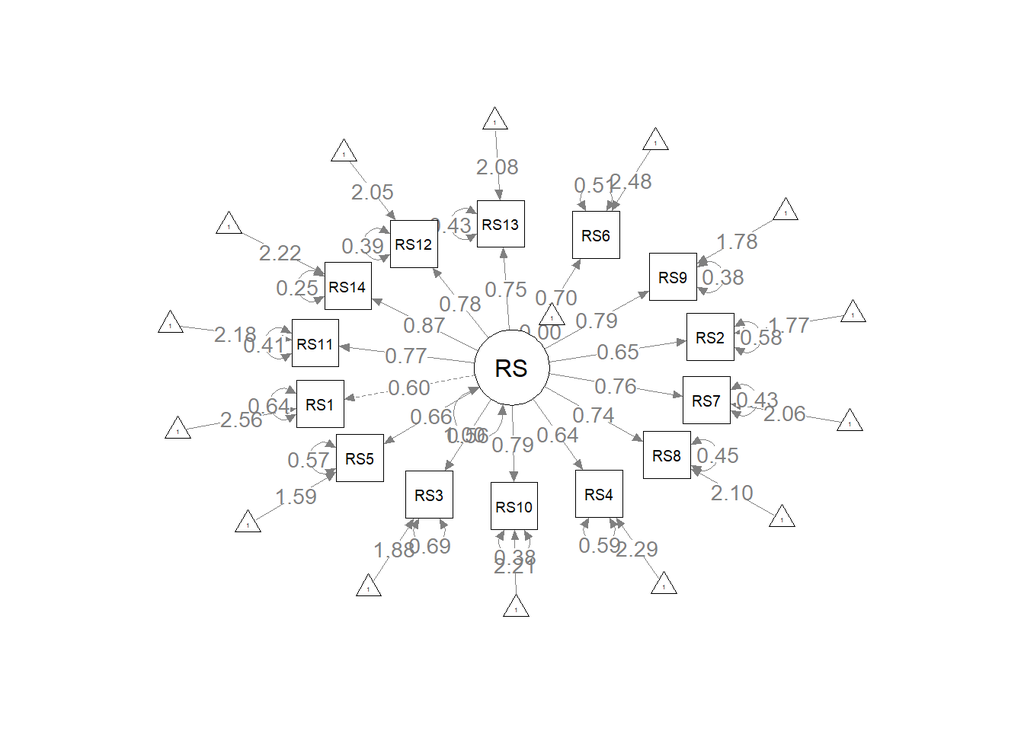

```r
semPaths(black.fit, whatLabels = "std", layout = "spring", edge.label.cex = 1)
```

## Add the fit to table

In the code below, we’ve started a table for our fit indices. Fill in the section labeled `#update here` with the same `round(fitmeasures(...))` code used in the first row.

```r
library(knitr)
table_fit <- matrix(NA, nrow = 8, ncol = 6)
colnames(table_fit) = c("Model", "X2", "df", "CFI", "RMSEA", "SRMR")
table_fit[1, ] <- c("Overall Model", round(fitmeasures(overall.fit,
                                                 c("chisq", "df", "cfi",
                                                   "rmsea", "srmr")),3))
kable(table_fit)
```

| Model | X2 | df | CFI | RMSEA | SRMR |
| --- | --- | --- | --- | --- | --- |
| Overall Model | 339.948 | 77 | 0.925 | 0.086 | 0.041 |
| NA | NA | NA | NA | NA | NA |
| NA | NA | NA | NA | NA | NA |
| NA | NA | NA | NA | NA | NA |
| NA | NA | NA | NA | NA | NA |
| NA | NA | NA | NA | NA | NA |
| NA | NA | NA | NA | NA | NA |
| NA | NA | NA | NA | NA | NA |

```r
table_fit[2, ] <- c("White Model", round(fitmeasures(white.fit,
                                                 c("chisq", "df", "cfi",
                                                   "rmsea", "srmr")),3))

table_fit[3, ] <- c("Black Model", round(fitmeasures(black.fit,
                                                 c("chisq", "df", "cfi",
                                                   "rmsea", "srmr")),3))

kable(table_fit)
```

| Model | X2 | df | CFI | RMSEA | SRMR |
| --- | --- | --- | --- | --- | --- |
| Overall Model | 339.948 | 77 | 0.925 | 0.086 | 0.041 |
| White Model | 342.834 | 77 | 0.902 | 0.098 | 0.047 |
| Black Model | 125.924 | 77 | 0.944 | 0.077 | 0.047 |
| NA | NA | NA | NA | NA | NA |
| NA | NA | NA | NA | NA | NA |
| NA | NA | NA | NA | NA | NA |
| NA | NA | NA | NA | NA | NA |
| NA | NA | NA | NA | NA | NA |

## Configural Invariance

Create a `configural.fit` model using `Ethnicity` as your group variable. Include a `summary()` of this model. Add in the `configural.fit` to your table.

```r
configural.fit = cfa(model = overall.model, data = data, meanstructure = T, group = "Ethnicity")
summary(configural.fit, standardized = T, rsquare = T, fit.measure = T)
```

```
## lavaan 0.6-7 ended normally after 62 iterations
##
##   Estimator                                         ML
##   Optimization method                           NLMINB
##   Number of free parameters                         84
##
##   Number of observations per group:
##     Black                                          106
##     White                                          358
##
## Model Test User Model:
##
##   Test statistic                               468.758
##   Degrees of freedom                               154
##   P-value (Chi-square)                           0.000
##   Test statistic for each group:
##     Black                                      125.924
##     White                                      342.834
##
## Model Test Baseline Model:
##
##   Test statistic                              3762.845
##   Degrees of freedom                               182
##   P-value                                        0.000
##
## User Model versus Baseline Model:
##
##   Comparative Fit Index (CFI)                    0.912
##   Tucker-Lewis Index (TLI)                       0.896
##
## Loglikelihood and Information Criteria:
##
##   Loglikelihood user model (H0)             -11834.717
##   Loglikelihood unrestricted model (H1)     -11600.338
##
##   Akaike (AIC)                               23837.434
##   Bayesian (BIC)                             24185.184
##   Sample-size adjusted Bayesian (BIC)        23918.589
##
## Root Mean Square Error of Approximation:
```

[output cut: 148 more lines]

```
##                    Estimate
##     RS1               0.410
##     RS2               0.471
##     RS3               0.428
##     RS4               0.476
##     RS5               0.445
##     RS6               0.545
##     RS7               0.563
##     RS8               0.469
##     RS9               0.515
##     RS10              0.433
##     RS11              0.541
##     RS12              0.411
##     RS13              0.544
##     RS14              0.629
```

```r
table_fit[4, ] <- c("Configural Model", round(fitmeasures(configural.fit,
                                                 c("chisq", "df", "cfi",
                                                   "rmsea", "srmr")),3))

kable(table_fit)
```

| Model | X2 | df | CFI | RMSEA | SRMR |
| --- | --- | --- | --- | --- | --- |
| Overall Model | 339.948 | 77 | 0.925 | 0.086 | 0.041 |
| White Model | 342.834 | 77 | 0.902 | 0.098 | 0.047 |
| Black Model | 125.924 | 77 | 0.944 | 0.077 | 0.047 |
| Configural Model | 468.758 | 154 | 0.912 | 0.094 | 0.047 |
| NA | NA | NA | NA | NA | NA |
| NA | NA | NA | NA | NA | NA |
| NA | NA | NA | NA | NA | NA |
| NA | NA | NA | NA | NA | NA |

## Metric Invariance

In this section, create `metric.fit`, summarize the model, and add the model information to your table.

```r
metric.fit = cfa(model = overall.model, data = data, meanstructure = T, group = "Ethnicity", group.equal = c("loadings"))
summary(metric.fit, standardized = T, rsquare = T, fit.measure = T)
```

```
## lavaan 0.6-7 ended normally after 48 iterations
##
##   Estimator                                         ML
##   Optimization method                           NLMINB
##   Number of free parameters                         84
##   Number of equality constraints                    13
##
##   Number of observations per group:
##     Black                                          106
##     White                                          358
##
## Model Test User Model:
##
##   Test statistic                               483.102
##   Degrees of freedom                               167
##   P-value (Chi-square)                           0.000
##   Test statistic for each group:
##     Black                                      136.499
##     White                                      346.603
##
## Model Test Baseline Model:
##
##   Test statistic                              3762.845
##   Degrees of freedom                               182
##   P-value                                        0.000
##
## User Model versus Baseline Model:
##
##   Comparative Fit Index (CFI)                    0.912
##   Tucker-Lewis Index (TLI)                       0.904
##
## Loglikelihood and Information Criteria:
##
##   Loglikelihood user model (H0)             -11841.889
##   Loglikelihood unrestricted model (H1)     -11600.338
##
##   Akaike (AIC)                               23825.778
##   Bayesian (BIC)                             24119.710
##   Sample-size adjusted Bayesian (BIC)        23894.374
##
```

[output cut: 149 more lines]

```
##                    Estimate
##     RS1               0.390
##     RS2               0.459
##     RS3               0.413
##     RS4               0.451
##     RS5               0.429
##     RS6               0.529
##     RS7               0.568
##     RS8               0.468
##     RS9               0.534
##     RS10              0.458
##     RS11              0.541
##     RS12              0.442
##     RS13              0.545
##     RS14              0.637
```

```r
table_fit[5, ] <- c("Metric Model", round(fitmeasures(metric.fit,
                                                 c("chisq", "df", "cfi",
                                                   "rmsea", "srmr")),3))

kable(table_fit)
```

| Model | X2 | df | CFI | RMSEA | SRMR |
| --- | --- | --- | --- | --- | --- |
| Overall Model | 339.948 | 77 | 0.925 | 0.086 | 0.041 |
| White Model | 342.834 | 77 | 0.902 | 0.098 | 0.047 |
| Black Model | 125.924 | 77 | 0.944 | 0.077 | 0.047 |
| Configural Model | 468.758 | 154 | 0.912 | 0.094 | 0.047 |
| Metric Model | 483.102 | 167 | 0.912 | 0.09 | 0.056 |
| NA | NA | NA | NA | NA | NA |
| NA | NA | NA | NA | NA | NA |
| NA | NA | NA | NA | NA | NA |

## Scalar Invariance

In this section, create `scalar.fit`, summarize the model, and add the model information to your table.

```r
scalar.fit = cfa(model = overall.model, data = data, meanstructure = T, group = "Ethnicity", group.equal = c("loadings", "intercepts"))
summary(scalar.fit, standardized = T, rsquare = T, fit.measure = T)
```

```
## lavaan 0.6-7 ended normally after 64 iterations
##
##   Estimator                                         ML
##   Optimization method                           NLMINB
##   Number of free parameters                         85
##   Number of equality constraints                    27
##
##   Number of observations per group:
##     Black                                          106
##     White                                          358
##
## Model Test User Model:
##
##   Test statistic                               533.891
##   Degrees of freedom                               180
##   P-value (Chi-square)                           0.000
##   Test statistic for each group:
##     Black                                      179.172
##     White                                      354.719
##
## Model Test Baseline Model:
##
##   Test statistic                              3762.845
##   Degrees of freedom                               182
##   P-value                                        0.000
##
## User Model versus Baseline Model:
##
##   Comparative Fit Index (CFI)                    0.901
##   Tucker-Lewis Index (TLI)                       0.900
##
## Loglikelihood and Information Criteria:
##
##   Loglikelihood user model (H0)             -11867.284
##   Loglikelihood unrestricted model (H1)     -11600.338
##
##   Akaike (AIC)                               23850.567
##   Bayesian (BIC)                             24090.680
##   Sample-size adjusted Bayesian (BIC)        23906.603
##
```

[output cut: 149 more lines]

```
##                    Estimate
##     RS1               0.390
##     RS2               0.458
##     RS3               0.413
##     RS4               0.452
##     RS5               0.428
##     RS6               0.529
##     RS7               0.566
##     RS8               0.468
##     RS9               0.534
##     RS10              0.458
##     RS11              0.540
##     RS12              0.438
##     RS13              0.544
##     RS14              0.637
```

```r
table_fit[6, ] <- c("Scalar Model", round(fitmeasures(scalar.fit,
                                                 c("chisq", "df", "cfi",
                                                   "rmsea", "srmr")),3))

kable(table_fit)
```

| Model | X2 | df | CFI | RMSEA | SRMR |
| --- | --- | --- | --- | --- | --- |
| Overall Model | 339.948 | 77 | 0.925 | 0.086 | 0.041 |
| White Model | 342.834 | 77 | 0.902 | 0.098 | 0.047 |
| Black Model | 125.924 | 77 | 0.944 | 0.077 | 0.047 |
| Configural Model | 468.758 | 154 | 0.912 | 0.094 | 0.047 |
| Metric Model | 483.102 | 167 | 0.912 | 0.09 | 0.056 |
| Scalar Model | 533.891 | 180 | 0.901 | 0.092 | 0.06 |
| NA | NA | NA | NA | NA | NA |
| NA | NA | NA | NA | NA | NA |

## Strict (Error) Invariance

Last, add `strict.fit` by including error variances in your multigroup model, summarize that model, and include the fit information in the table.

```r
strict.fit = cfa(model = overall.model, data = data, meanstructure = T, group = "Ethnicity", group.equal = c("loadings", "intercepts", "residuals"))
summary(strict.fit, standardized = T, rsquare = T, fit.measure = T)
```

```
## lavaan 0.6-7 ended normally after 45 iterations
##
##   Estimator                                         ML
##   Optimization method                           NLMINB
##   Number of free parameters                         85
##   Number of equality constraints                    41
##
##   Number of observations per group:
##     Black                                          106
##     White                                          358
##
## Model Test User Model:
##
##   Test statistic                               601.591
##   Degrees of freedom                               194
##   P-value (Chi-square)                           0.000
##   Test statistic for each group:
##     Black                                      219.872
##     White                                      381.719
##
## Model Test Baseline Model:
##
##   Test statistic                              3762.845
##   Degrees of freedom                               182
##   P-value                                        0.000
##
## User Model versus Baseline Model:
##
##   Comparative Fit Index (CFI)                    0.886
##   Tucker-Lewis Index (TLI)                       0.893
##
## Loglikelihood and Information Criteria:
##
##   Loglikelihood user model (H0)             -11901.134
##   Loglikelihood unrestricted model (H1)     -11600.338
##
##   Akaike (AIC)                               23890.267
##   Bayesian (BIC)                             24072.422
##   Sample-size adjusted Bayesian (BIC)        23932.777
##
```

[output cut: 149 more lines]

```
##                    Estimate
##     RS1               0.364
##     RS2               0.423
##     RS3               0.364
##     RS4               0.410
##     RS5               0.408
##     RS6               0.497
##     RS7               0.533
##     RS8               0.465
##     RS9               0.518
##     RS10              0.459
##     RS11              0.519
##     RS12              0.431
##     RS13              0.524
##     RS14              0.634
```

```r
table_fit[7, ] <- c("Strict Model", round(fitmeasures(strict.fit,
                                                 c("chisq", "df", "cfi",
                                                   "rmsea", "srmr")),3))

kable(table_fit)
```

| Model | X2 | df | CFI | RMSEA | SRMR |
| --- | --- | --- | --- | --- | --- |
| Overall Model | 339.948 | 77 | 0.925 | 0.086 | 0.041 |
| White Model | 342.834 | 77 | 0.902 | 0.098 | 0.047 |
| Black Model | 125.924 | 77 | 0.944 | 0.077 | 0.047 |
| Configural Model | 468.758 | 154 | 0.912 | 0.094 | 0.047 |
| Metric Model | 483.102 | 167 | 0.912 | 0.09 | 0.056 |
| Scalar Model | 533.891 | 180 | 0.901 | 0.092 | 0.06 |
| Strict Model | 601.591 | 194 | 0.886 | 0.095 | 0.062 |
| NA | NA | NA | NA | NA | NA |

QUESTION: Looking at your results, do you see anywhere that indicates non-invariance (i.e., has a larger change than CFI = .01)? Where did it appear to break down?  
ANSWER: Yes, it broke when building Scalar Model

## Partial Invariance

Use the code provided from class to calculate the potential pathway that should be freed to improve our model fit for partial invariance.

```r
partial_syntax = paste(colnames(data)[4:17], "~~", colnames(data)[4:17])
CFI_list  <- 1:length(partial_syntax)
names(CFI_list) <- partial_syntax

for (i in 1:length(partial_syntax)){
  temp <- cfa(model = overall.model,
              data = data,
              meanstructure = TRUE,
              group = "Ethnicity",
              group.equal = c("loadings", "intercepts", "residuals"),
              group.partial = partial_syntax[i])
  CFI_list[i] <- fitmeasures(temp, "cfi")
}
which.max(CFI_list)
```

```
## RS3 ~~ RS3
##          2
```

## Update the Model

Create `partial.fit` by updating your model to allow for the freed parameter. Summarize the model, and add this model’s fit information to your table.

```r
partial.fit <- cfa(model = overall.model, data = data, meanstructure = TRUE, group = "Ethnicity", group.equal = c("loadings", "intercepts", "residuals"), group.partial = c("RS3 ~~ RS3"))

summary(partial.fit, standardized = T, rsquare = T, fit.measure = T)
```

```
## lavaan 0.6-7 ended normally after 53 iterations
##
##   Estimator                                         ML
##   Optimization method                           NLMINB
##   Number of free parameters                         85
##   Number of equality constraints                    40
##
##   Number of observations per group:
##     Black                                          106
##     White                                          358
##
## Model Test User Model:
##
##   Test statistic                               586.056
##   Degrees of freedom                               193
##   P-value (Chi-square)                           0.000
##   Test statistic for each group:
##     Black                                      209.230
##     White                                      376.827
##
## Model Test Baseline Model:
##
##   Test statistic                              3762.845
##   Degrees of freedom                               182
##   P-value                                        0.000
##
## User Model versus Baseline Model:
##
##   Comparative Fit Index (CFI)                    0.890
##   Tucker-Lewis Index (TLI)                       0.896
##
## Loglikelihood and Information Criteria:
##
##   Loglikelihood user model (H0)             -11893.366
##   Loglikelihood unrestricted model (H1)     -11600.338
##
##   Akaike (AIC)                               23876.733
##   Bayesian (BIC)                             24063.028
##   Sample-size adjusted Bayesian (BIC)        23920.209
##
```

[output cut: 149 more lines]

```
##                    Estimate
##     RS1               0.364
##     RS2               0.425
##     RS3               0.413
##     RS4               0.411
##     RS5               0.408
##     RS6               0.496
##     RS7               0.533
##     RS8               0.464
##     RS9               0.517
##     RS10              0.458
##     RS11              0.519
##     RS12              0.431
##     RS13              0.522
##     RS14              0.637
```

```r
table_fit[8, ] <- c("Partial Model", round(fitmeasures(partial.fit, c("chisq", "df", "cfi", "rmsea", "srmr")),3))

kable(table_fit)
```

| Model | X2 | df | CFI | RMSEA | SRMR |
| --- | --- | --- | --- | --- | --- |
| Overall Model | 339.948 | 77 | 0.925 | 0.086 | 0.041 |
| White Model | 342.834 | 77 | 0.902 | 0.098 | 0.047 |
| Black Model | 125.924 | 77 | 0.944 | 0.077 | 0.047 |
| Configural Model | 468.758 | 154 | 0.912 | 0.094 | 0.047 |
| Metric Model | 483.102 | 167 | 0.912 | 0.09 | 0.056 |
| Scalar Model | 533.891 | 180 | 0.901 | 0.092 | 0.06 |
| Strict Model | 601.591 | 194 | 0.886 | 0.095 | 0.062 |
| Partial Model | 586.056 | 193 | 0.89 | 0.094 | 0.061 |